# PML Course Project

Viacheslav Shybaiev

November 23, 2014

# Introduction

This is an Practical Machine Learning course projest. The assignment objective is to build the learning algorythm to the Human Activity Recognitiondata set of 6 participants who were asked to perform barbell lifting activities correctly and incorrectly in 5 different ways.

Data set credits: Velloso, E.; Bulling, A.; Gellersen, H.; Ugulino, W.; Fuks, H. Qualitative Activity Recognition of Weight Lifting Exercises. Proceedings of 4th International Conference in Cooperation with SIGCHI (Augmented Human ’13) . Stuttgart, Germany: ACM SIGCHI, 2013.

Read more: http://groupware.les.inf.puc-rio.br/har#ixzz3JtzTNxAi

# Processing Data

Reading the raw data from CSV files and building the training model on the *classe* factor against the non-empty columns of the training set: roll_belt, pitch_belt, yaw_belt, gyros_belt_x, gyros_belt_y, gyros_belt_z, accel_belt_x, accel_belt_y, accel_belt_z, magnet_belt_x, magnet_belt_y, magnet_belt_z, roll_arm, pitch_arm, yaw_arm, total_accel_arm, gyros_arm_x, gyros_arm_y, gyros_arm_z, accel_arm_x, accel_arm_y, accel_arm_z, magnet_arm_x, magnet_arm_y, magnet_arm_z, roll_dumbbell, and yaw_dumbbell.

We’re using the Random Forest algorithm for the training model.

```r
rawTrain = read.csv ("pml-training.csv")
rawTest = read.csv ("pml-testing.csv")

fit = train (classe ~ roll_belt + pitch_belt + yaw_belt + gyros_belt_x +
                     gyros_belt_y + gyros_belt_z + accel_belt_x + accel_belt_y +
                     accel_belt_z + magnet_belt_x + magnet_belt_y + magnet_belt_z +
                     roll_arm + pitch_arm + yaw_arm + total_accel_arm + gyros_arm_x +
                     gyros_arm_y + gyros_arm_z + accel_arm_x + accel_arm_y + accel_arm_z +
                     magnet_arm_x + magnet_arm_y + magnet_arm_z + roll_dumbbell +
                     yaw_dumbbell, method = "rf", data=rawTrain)
```

## Overview of the model

```r
print(fit)
```

[output not shown]

The test set contsist of 20 test cases which we’re going to classify on the *classe* factor.

Call predict function from the caret package:

```r
predict(fit, rawTest)
```

```
##  [1] B A B A A E D B A A B C B A E E A B B B
## Levels: A B C D E
```

As seen above, there are 20 classifications for each of the test cases.

## Estimate of sample error

We’re using plot of the final model to estimate the sample error:

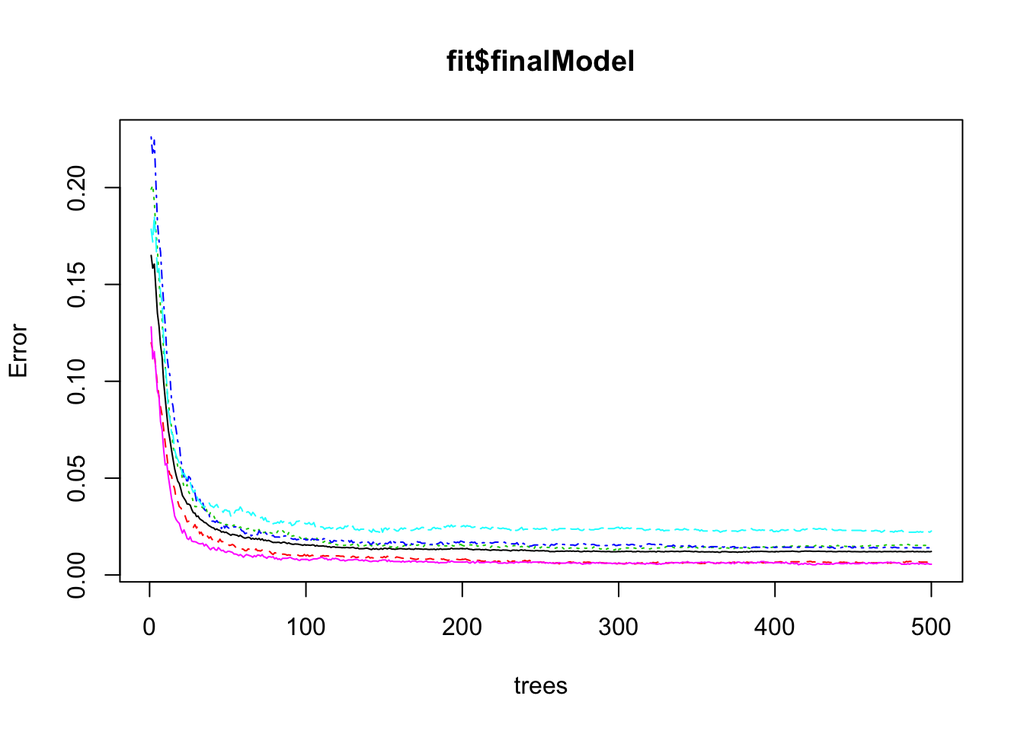

## Variable Importance

Further model optimisation could be done using the variable importance order:

```r
varImp(fit)
```

```
## rf variable importance
##
##   only 20 most important variables shown (out of 27)
##
##               Overall
## roll_belt       100.0
## yaw_belt         90.8
## pitch_belt       65.8
## roll_dumbbell    63.8
## yaw_dumbbell     44.9
## roll_arm         43.5
## magnet_belt_z    42.3
## accel_belt_z     41.1
## magnet_belt_y    36.9
## magnet_arm_y     29.6
## accel_arm_x      27.6
## magnet_arm_x     27.3
## magnet_belt_x    25.8
## yaw_arm          23.5
## gyros_belt_z     22.7
## pitch_arm        22.6
## accel_arm_z      21.5
## magnet_arm_z     21.1
## accel_arm_y      20.0
## gyros_arm_y      16.8
```

# Summary

In this assignment we performed very basic machine learning excersise building the training model and using the Ranfom Forest algorithm.